# Rockies Fire Analysis

Stephen Huysman

2023-05-16

# Settings

```r
library(tidyverse)
library(multidplyr)
library(zoo)
library(slider)
library(pROC)

plot_theme <- theme_bw()

cores <- parallel::detectCores() - 4
cluster <- new_cluster(cores)

window <- 7 ## Window of days to calculate rolling values
vars <- c("RD", "VPD", "T", "SOIL", "AWSSM", "RAIN", "AET", "D", "GDD")

region_name <- "Southern Rockies"  ## Set region name, should be same as L3 Ecoregion name

settings <- tribble(
    ~region, ~params,
    "Southern Rockies", list(data_dir =  "/home/steve/OneDrive/nothern-rockies-dryness",
                           out_dir =  "/media/steve/storage/waterbalance/fire/out/ap23/",
                           master_csv =  "SR_fire_points_extracted.csv"
                           ),
    "Middle Rockies", list(data_dir =  "/home/steve/OneDrive/nothern-rockies-dryness",
                           out_dir =  "/media/steve/storage/waterbalance/fire/out/",
                           master_csv =  "MR_fire_points_extracted.csv"
                           ),
)


settings <- settings %>% filter(region == region_name)

## Directory containing metadata file
data_dir <- settings$params[[1]]$data_dir

## Directory with csv files from merge-csv.R
out_dir <- settings$params[[1]]$out_dir

master_csv <- settings$params[[1]]$master_csv
```

# Preprocessing

1. Get MTBS database
- Extract fire polys by location of interest (Ecoregion)
- Create centroids for each poly (Pole of inaccessability in QGIS)
2. Get LANDFIRE EVT (Existing Vegetation Type data)
- Use statistics tool in QGIS to get mean, median, and mode EVT by pixel count. Only mode is used going further.
3. Create master csv file with points of interest. Needs columns ‘Event_ID’, ‘Incid_Type’, ‘Ig_Date’, ‘x’ (=Longitude), ‘y’ (=Latitiude), and ‘LF20_EVT_5’ (Landfire 2020 EVT type). Further analysis can look at finer resolution LANDFIRE vegetation types offered.
4. Get Historical WB data for each centroid from Mike
5. Get Historical gridmet climate data for Each centroid
- gridmet-historical.R - download gridmet data for each point
  - pr, tmmx, tmmn, rmax, rmin, vpd
  - creates one dir ‘gridmet-$var’ for each variable
- merge-csv.R
  - join Mike’s data and historical gridmet data into one csv for each Event_ID
  - use these csvs for input to this script

# Master dataframe

Read in file containing meta data for fires of interest.

```r
setwd(data_dir)

master <- read_csv(master_csv) %>%
    filter(Incid_Type == "Wildfire") %>%
##    filter(year(Ig_Date) <= 2014) %>%
    rename("maj_veg_cl" = LF20_EVT_5,
           "Acres" = BurnBndAc) %>%
    ##  maj_class is the majority
    ##    of pixels classification from Landfire 30m pixels in burned
    ##    areas, this data was extracted in QGIS.
    mutate(maj_veg_cl = case_match(maj_veg_cl,
                                   c("Herb", "Shrub", "Sparse") ~ "non-forest",
                                   "Tree" ~ "forest",
                                   c("Agriculture", "Water") ~ "other"),
           filename = paste0(Event_ID, ".csv"),
           doy = yday(Ig_Date))
```

# Map

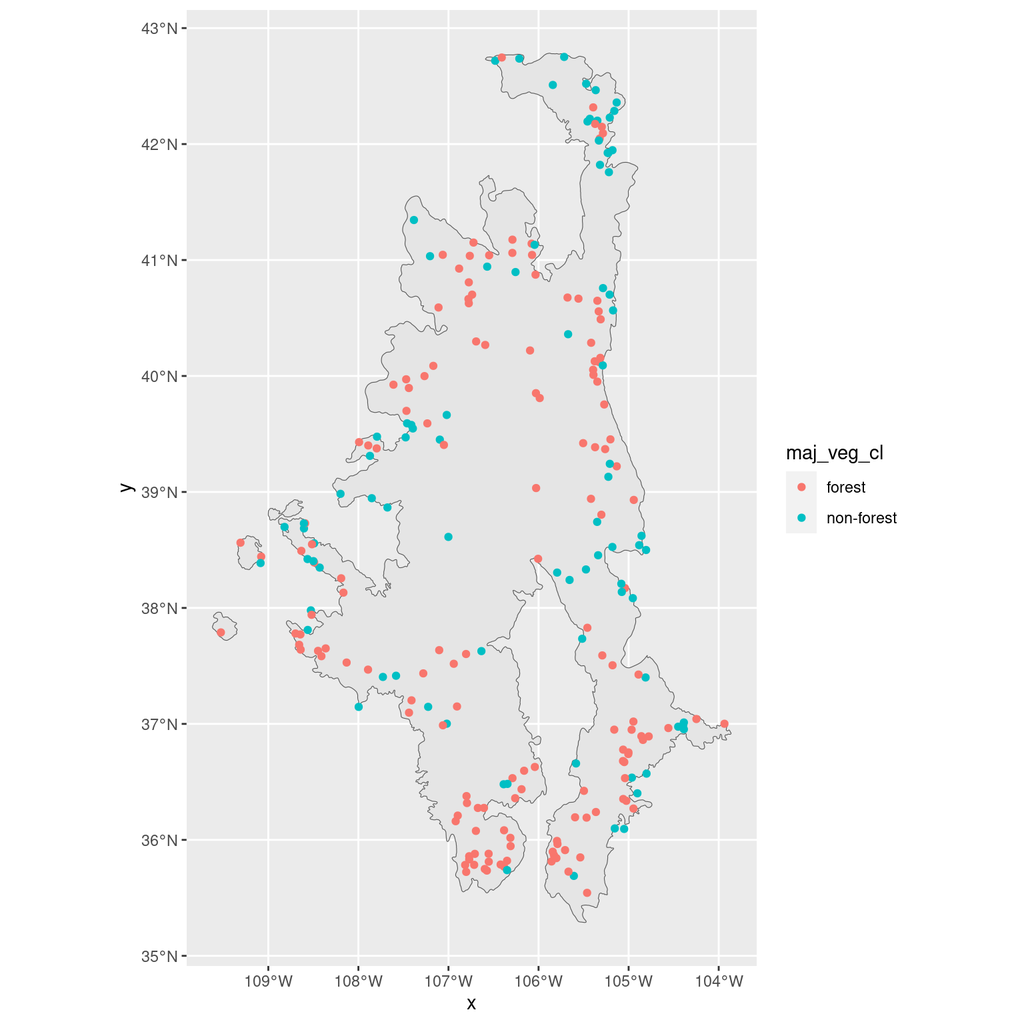

```r
library(sp)
library(sf)

coords <- data.frame(
    x = master$x,
    y = master$y
)
spdf <- SpatialPointsDataFrame(coords = coords, data = master)

ecoregions <- st_transform(read_sf("/home/steve/OneDrive/nothern-rockies-dryness/data/us_eco_l3/us_eco_l3.shp"), crs = 4326)
ecoregion <- ecoregions %>% filter(US_L3NAME == region_name)

ggplot(ecoregion) +
    geom_sf() +
    geom_point(data = master, aes(x, y, color = maj_veg_cl))
```

```r
summary_tbl <- master %>% group_by(maj_veg_cl) %>% summarise(n = n())
knitr::kable(summary_tbl)
```

| maj_veg_cl | n |
| --- | --- |
| forest | 153 |
| non-forest | 86 |

# Determine Fire Season

```r
forest<-subset(master, maj_veg_cl=="forest")
forest_q<-quantile(forest$doy,c(0,1))#90% of data fall within this range 0.05-0.95# 0.27 to 0.75 or 0,1 to determine min max

nonforest<-subset(master, maj_veg_cl=="non-forest")
nonforest_q<-quantile(nonforest$doy,c(0,1))#90% of data fall within this range 0.05-0.95# 0.27 to 0.75 or 0,1 to determine min

#start and end dates of fire season by vegetation type derived from day of year in min_max table
doy_min_max<-as.data.frame(rbind(forest_q, nonforest_q))
forest_start<-doy_min_max[1,1]
nonforest_start<-doy_min_max[2,1]
forest_end<-doy_min_max[1,2]
nonforest_end<-doy_min_max[2,2]

knitr::kable(doy_min_max)
```

|  | 0% | 100% |
| --- | --- | --- |
| forest_q | 79 | 303 |
| nonforest_q | 7 | 301 |

# Compute Percentiles

```r
cluster_copy(cluster, "master")
cluster_copy(cluster, "window")
cluster_copy(cluster, "vars")
cluster_copy(cluster, "forest_start")
cluster_copy(cluster, "nonforest_start")
cluster_copy(cluster, "forest_end")
cluster_copy(cluster, "nonforest_end")
cluster_library(cluster, 'tidyverse')
cluster_library(cluster, 'slider')
cluster_library(cluster, 'zoo')


files <- paste0(out_dir, master$filename)
cluster_assign_partition(cluster, files = files)
cluster_send(cluster, wbdata <- vroom::vroom(files, id = "PATH"))
wbdata <- party_df(cluster, "wbdata")
master <- party_df(cluster, "master")

wbdata <- wbdata %>%
    mutate(Event_ID = str_extract(PATH, '(?<=/)[^/]*(?=\\.[^./]+$)')) %>% ## Extract file name without extension, use as Event_ID
    group_by(Event_ID) %>%
    mutate(RD = 100 - RH,
           WHC = max(SOIL), ## Guestimate soil WHC from max soil moisture observed
           AWSSM = WHC - SOIL) %>%
    left_join(select(master,
                     Event_ID, Ig_Date, maj_veg_cl, Acres),
              by = "Event_ID") %>%
    mutate(fire = if_else(Date == Ig_Date, 1, 0))

start <- proc.time() # Start clock
wbdata_smoothed <- select(wbdata, c(Event_ID, Ig_Date, maj_veg_cl, Acres, fire, Date, vars)) %>%
    ## mutate_at(vars[1:5],
    ##           ~ slide_dbl(.x, mean, .before = window, .after = 0, .complete = TRUE)) %>%
    ## mutate_at(vars[6:9],
    ##           ~ slide_dbl(.x, sum, .before = window, .after = 0, .complete = TRUE)) %>%
    mutate_at(vars[1:5],
              ~ rollapply(.x, window, mean, by = 1, partial = FALSE, fill = NA, align = "right")) %>%
    mutate_at(vars[6:9],
              ~ rollapply(.x, window, sum, by = 1, partial = FALSE, fill = NA, align = "right"))
time_elapsed_parallel <- proc.time() - start # End clock

wbdata_percentiles_forest <- select(wbdata_smoothed, c(Event_ID, Ig_Date, maj_veg_cl, Acres, fire, Date, vars)) %>%
    filter(maj_veg_cl == "forest") %>%
    filter(Date <= Ig_Date,
           yday(Date) >= forest_start, ## Filter to fire season
           yday(Date) <= forest_end) %>%  ## To get this to match results from original dryness_script2, we only filter beginning of season.  Original script also didn't use doy, instead it filtered by absolute date, so would only chop off first pre-fireseason from first year in record.
##    slice(window + 1):n()) %>%
    collect() %>%
    drop_na(vars) %>% ### Drop NAs from periods not included in rolling calcs
    mutate(across(vars,
                  percent_rank))

wbdata_percentiles_nonforest <- select(wbdata_smoothed, c(Event_ID, Ig_Date, maj_veg_cl, Acres, fire, Date, vars)) %>%
    filter(maj_veg_cl == "non-forest") %>%
    filter(Date <= Ig_Date,
           yday(Date) >= nonforest_start,  ## Filter to fire season
           yday(Date) <= nonforest_end) %>%
    ##        slice((window + 1):n()) %>%
    collect() %>%
    drop_na(vars) %>% ### Drop NAs from periods not included in rolling calcs
    mutate(across(vars,
                  percent_rank))

ignitions_forest <- wbdata_percentiles_forest %>% filter(fire == 1)
nonignitions_forest <- wbdata_percentiles_forest %>% filter(fire == 0)
ignitions_forest_long <- ignitions_forest %>% pivot_longer(cols = vars)
ignitions_nonforest <- wbdata_percentiles_nonforest %>% filter(fire == 1)
nonignitions_nonforest <- wbdata_percentiles_nonforest %>% filter(fire == 0)
ignitions_nonforest_long <- ignitions_nonforest %>% pivot_longer(cols = vars)
ignitions_long <- rbind(ignitions_forest_long, ignitions_nonforest_long)
```

# Corrplot

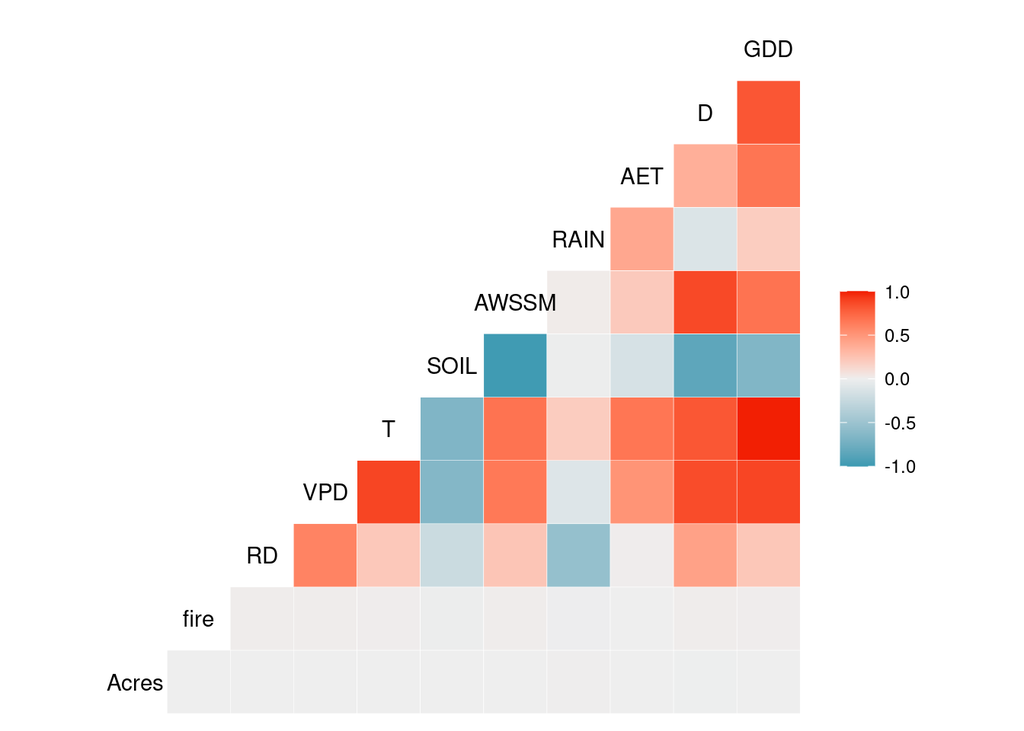

```r
library(GGally)

ggcorr(wbdata_percentiles_forest, method = c("everything", "pearson"))
```

# ROC Analysis

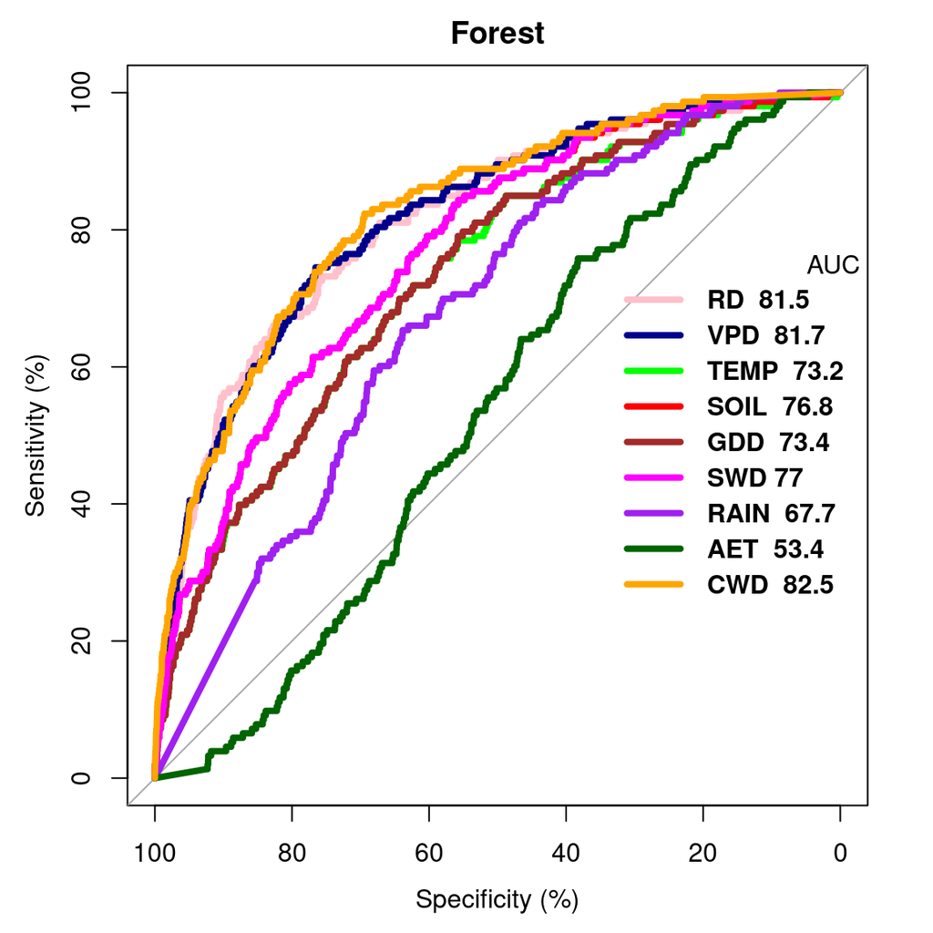

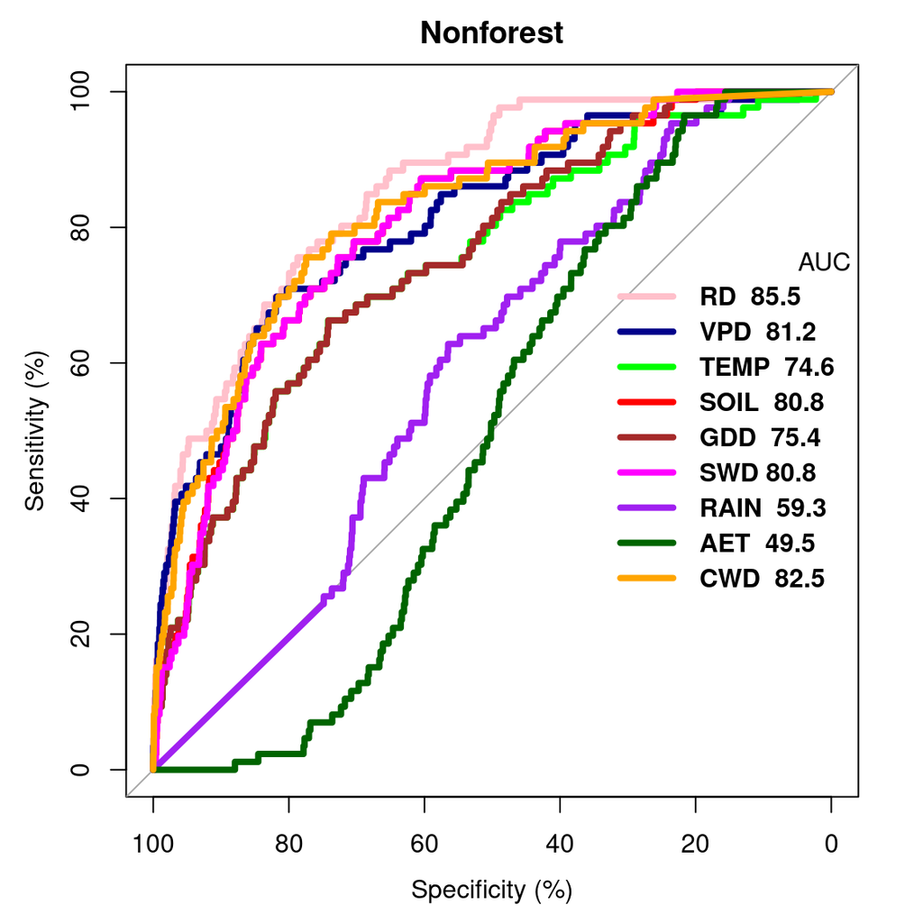

demonstrate histogram of conditions associated with fire or no fire to see how much overlap there is. This helps interpret the ROC

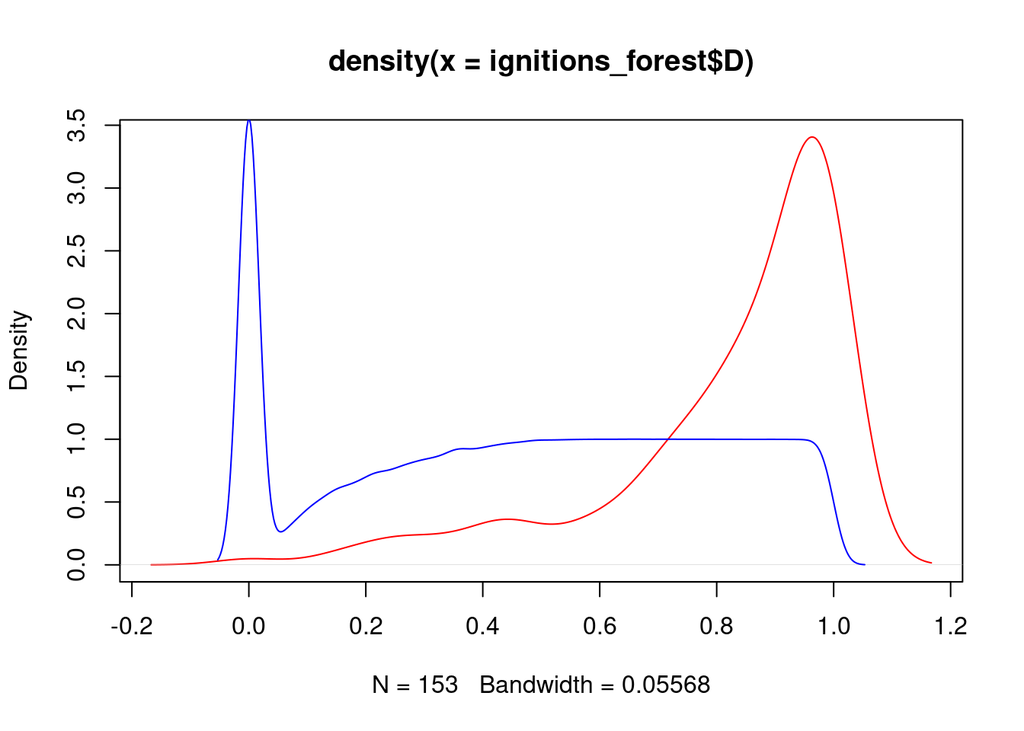

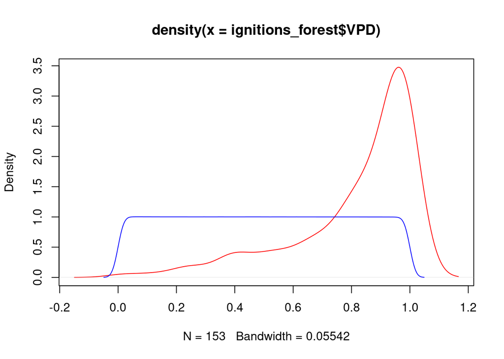

Determine contribution of various parameters to burned area

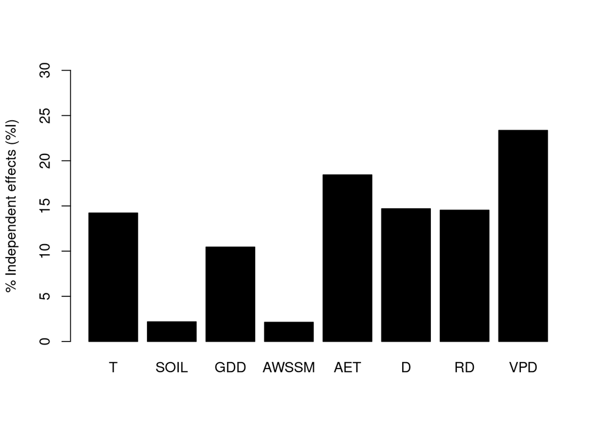

[output not shown]

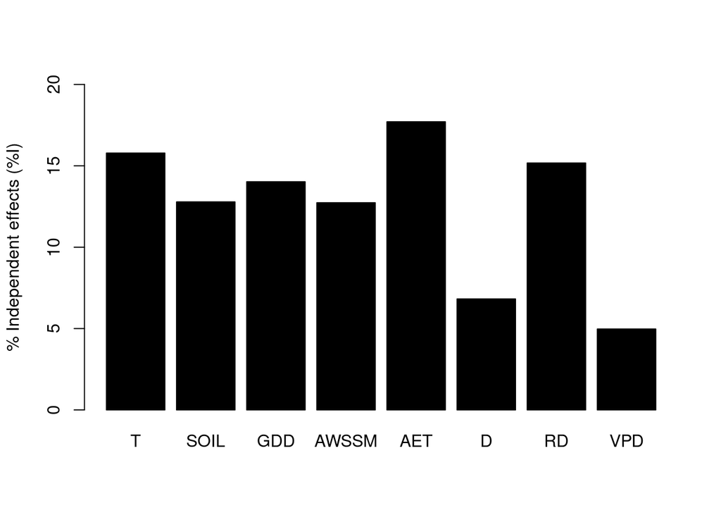

[output not shown]

Plots of wb percentile vs. area burned show weak relationships

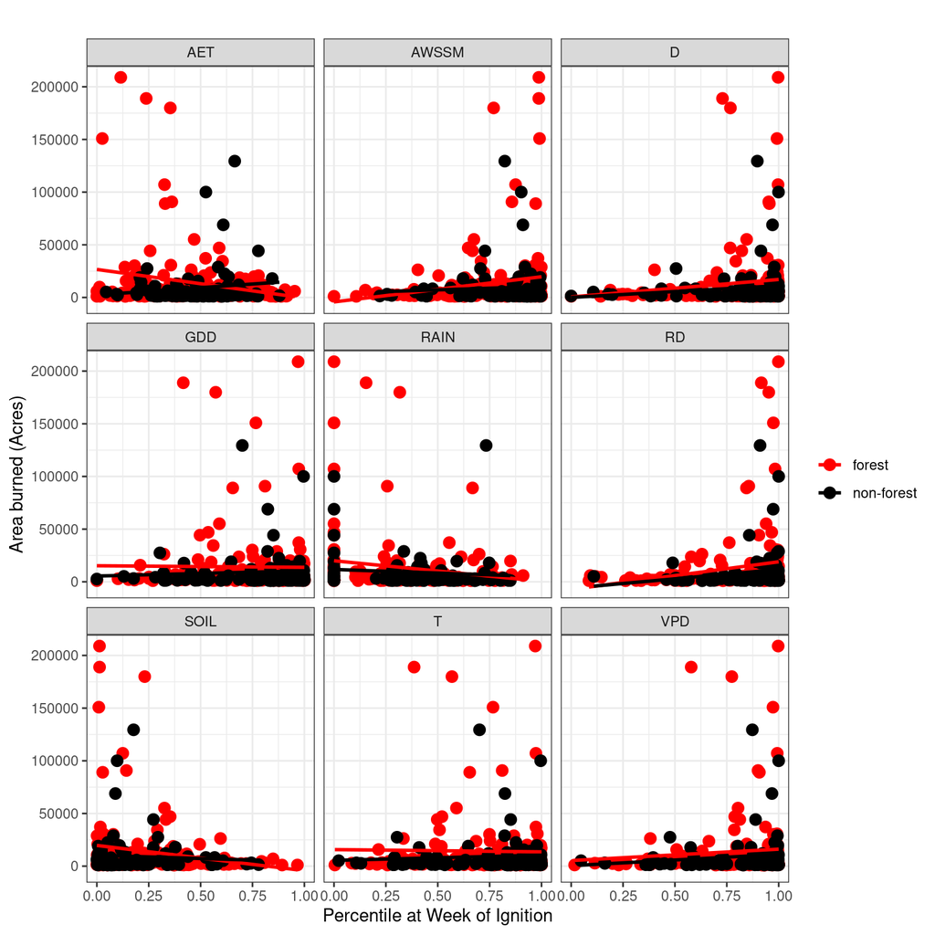

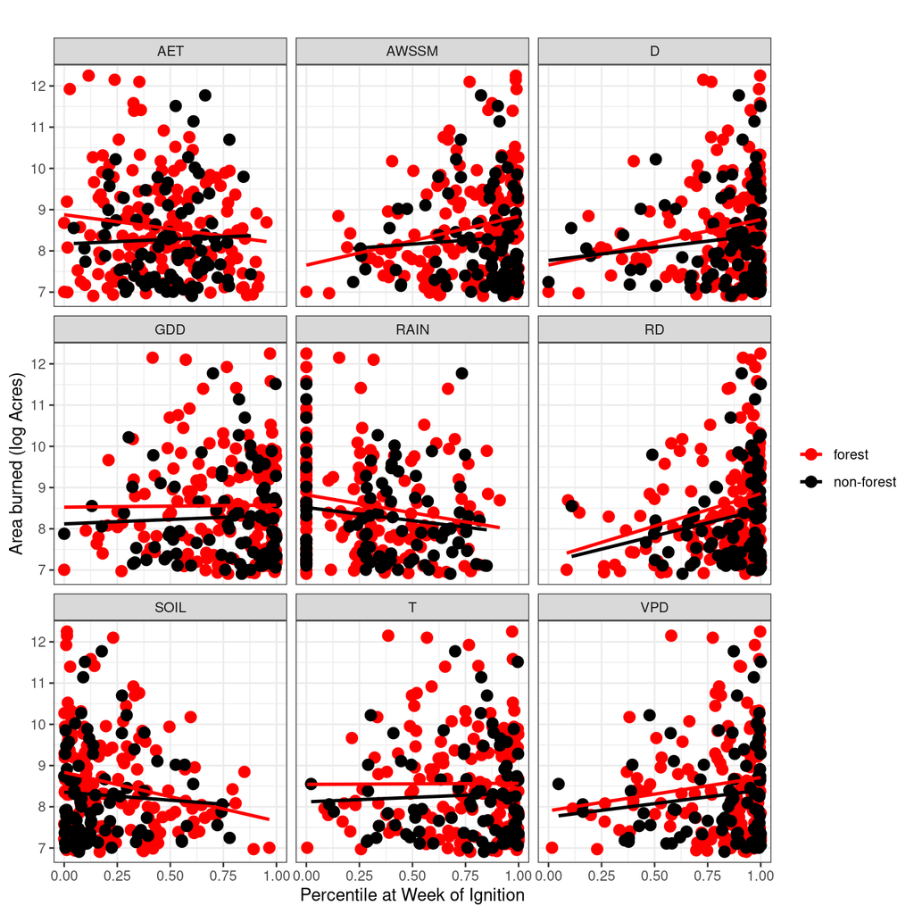

# ECDF

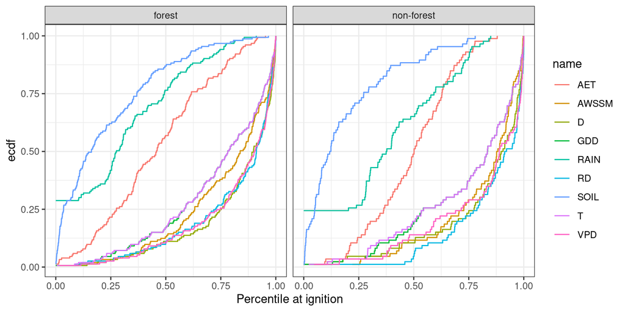

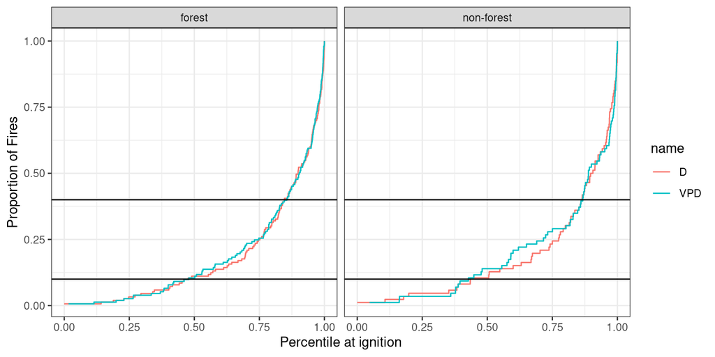

# Fire Danger Model

```r
regression_formulas <- tribble(
    ~cover, ~var, ~order, ~formula, ~r2
)

precision <- 7

regression1_formula <- function(a, b) {
    ## Regression formula in string format
    a <- round(a, precision)
    b <- round(b, precision)
    return (paste0("y = ", a, "e^(", b, "x)"))
}

regression2_formula <- function(b0, b1, b2) {
    ## Regression formula in string format
    b0 <- round(b0, precision)
    b1 <- round(b1, precision)
    b2 <- round(b2, precision)
    return (paste0("y = e^(", b0, " + ", b1, "x + ", b2, "x^2)"))
}

regression3_formula <- function(b0, b1, b2, b3) {
    ## Regression formula in string format
    b0 <- round(b0, precision)
    b1 <- round(b1, precision)
    b2 <- round(b2, precision)
    b3 <- round(b3, precision)
    return (paste0("y = e^(", b0, " + ", b1, "x + ", b2, "x^2 + ", b3, "x^3)"))
}
```

## First Order

```r
ecdf_regression1 <- function(ecdf_fn) {
    estimated <- data.frame(
        dec = seq(from = 0.01, to = 0.99, by = 0.01)
    )

    estimated$quants <- quantile(ecdf_fn, estimated$dec)
    estimated$proportions <- ecdf_fn(estimated$quants)

    lm <- lm(log(proportions) ~ quants, data = estimated)
    estimated$predicted <- exp(predict(lm, data = estimated$quants))

    ##plot(lm)

    a <- exp(lm$coefficients[[1]])
    b <- lm$coefficients[[2]]

    return (list(lm = lm,
                 estimated = estimated,
                 a = a,
                 b = b))
}
```

```r
ecdf_regression1_plot <- function(ecdf_fn, estimated, a, b) {
    high_thresh <- .4
    low_thresh <- .1

    regression_fn <- function(x) {
        a <- a
        b <- b
        return (a*exp(b*x))
    }

    plot(ecdf_fn)
    points(y = estimated$proportions, x = estimated$quants, col = "blue")
    points(y = estimated$predicted, x = estimated$quants, col = "red")
    curve(regression_fn, add = TRUE, col = "red")
    x_low <- round(log(low_thresh/a)/b,2)
    segments(0, low_thresh, x1 = x_low, y1 = low_thresh) ## Low Fire Danger horiz
    text(x = .3, y = low_thresh + 0.02, label = "Low Fire Danger")
    segments(x_low, 0, x1 = x_low, y1 = low_thresh) ## Low Fire Danger vert
    text(x = x_low, y = -.02, label = x_low)
    x_high <- round(log(high_thresh/a)/b,2)
    segments(0, high_thresh, x1 = x_high, y1 = high_thresh) ## High Fire Danger horiz
    text(x = .3, y = high_thresh + 0.02, label = "High Fire Danger")
    segments(x_high, 0, x1 = x_high, y1 = high_thresh) ## High Fire Danger vert
    text(x = x_high, y = -.02, label = x_high)
}
```

### CWD Forest

```r
ecdf_fn <- ecdf(ignitions_forest$D)
summary(ecdf_fn)
```

```
## Empirical CDF:     151 unique values with summary
##    Min. 1st Qu.  Median    Mean 3rd Qu.    Max.
##  0.0000  0.7487  0.8914  0.8201  0.9779  1.0000
```

```r
regression_list <- ecdf_regression1(ecdf_fn)
estimated <- regression_list$estimated
lm <- regression_list$lm
r2 <- summary(lm)$adj.r.squared
a <- regression_list$a
b <- regression_list$b

summary(lm)
```

```
##
## Call:
## lm(formula = log(proportions) ~ quants, data = estimated)
##
## Residuals:
##      Min       1Q   Median       3Q      Max
## -0.42422 -0.06176 -0.02902  0.05981  0.26027
##
## Coefficients:
##             Estimate Std. Error t value Pr(>|t|)
## (Intercept)  -4.6532     0.0440 -105.75   <2e-16 ***
## quants        4.4557     0.0517   86.18   <2e-16 ***
## ---
## Signif. codes:  0 '***' 0.001 '**' 0.01 '*' 0.05 '.' 0.1 ' ' 1
##
## Residual standard error: 0.1022 on 97 degrees of freedom
## Multiple R-squared:  0.9871, Adjusted R-squared:  0.987
## F-statistic:  7428 on 1 and 97 DF,  p-value: < 2.2e-16
```

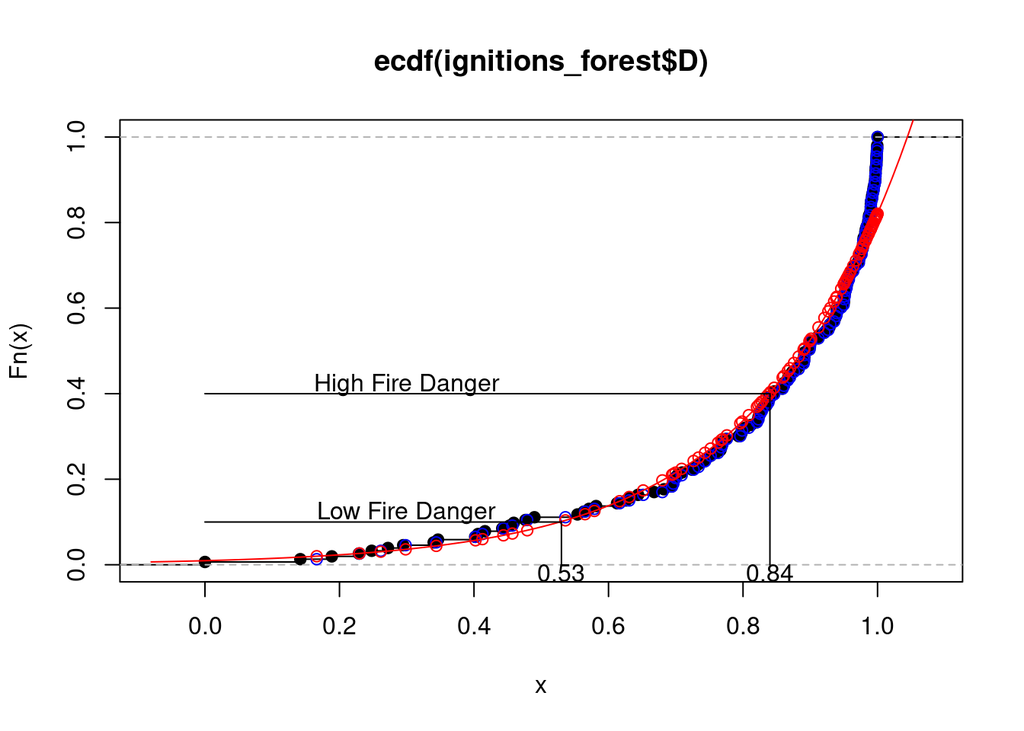

```r
ecdf_regression1_plot(ecdf_fn, estimated, a, b)
```

```r
regression_formulas <- regression_formulas %>%
    add_row(var = "D", order = "1", cover = "forest", formula = regression1_formula(a, b), r2 = r2)
```

Estimated function predicting proportion of historic fires burning in forests at or below given percentile of climatic water deficit on day of ignition:

$\begin{align*}f(x) = 0.0095308 e^{4.4556479 x}\end{align*}$

### VPD Forest

```r
ecdf_fn <- ecdf(ignitions_forest$VPD)
summary(ecdf_fn)
```

```
## Empirical CDF:     152 unique values with summary
##    Min. 1st Qu.  Median    Mean 3rd Qu.    Max.
## 0.01662 0.74359 0.90232 0.81565 0.97279 1.00000
```

```r
regression_list <- ecdf_regression1(ecdf_fn)
estimated <- regression_list$estimated
lm <- regression_list$lm
r2 <- summary(lm)$adj.r.squared
a <- regression_list$a
b <- regression_list$b

summary(lm)
```

```
##
## Call:
## lm(formula = log(proportions) ~ quants, data = estimated)
##
## Residuals:
##      Min       1Q   Median       3Q      Max
## -0.47371 -0.07345 -0.02498  0.06836  0.26426
##
## Coefficients:
##             Estimate Std. Error t value Pr(>|t|)
## (Intercept) -4.55612    0.04441 -102.58   <2e-16 ***
## quants       4.36876    0.05247   83.26   <2e-16 ***
## ---
## Signif. codes:  0 '***' 0.001 '**' 0.01 '*' 0.05 '.' 0.1 ' ' 1
##
## Residual standard error: 0.1057 on 97 degrees of freedom
## Multiple R-squared:  0.9862, Adjusted R-squared:  0.9861
## F-statistic:  6932 on 1 and 97 DF,  p-value: < 2.2e-16
```

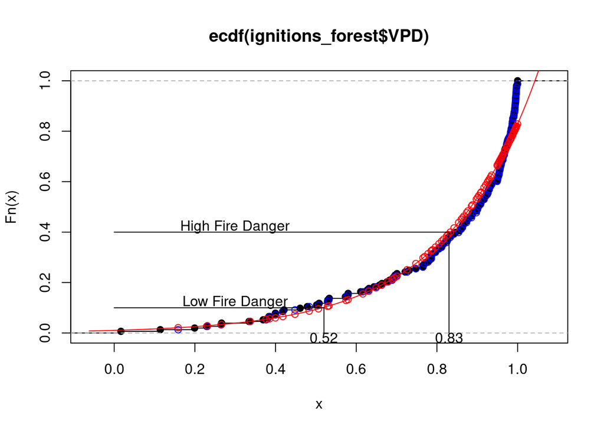

```r
ecdf_regression1_plot(ecdf_fn, estimated, a, b)
```

```r
regression_formulas <- regression_formulas %>%
    add_row(var = "VPD", order = "1", cover = "forest", formula = regression1_formula(a, b), r2 = r2)
```

Estimated function predicting proportion of historic fires burning in forests at or below given percentile of vapor pressure deficit on day of ignition:

$\begin{align*}f(x) = 0.0105027 e^{4.3687578 x}\end{align*}$

### CWD Non-Forest

```r
ecdf_fn <- ecdf(ignitions_nonforest$D)
summary(ecdf_fn)
```

```
## Empirical CDF:     86 unique values with summary
##    Min. 1st Qu.  Median    Mean 3rd Qu.    Max.
##  0.0000  0.7748  0.9015  0.8195  0.9772  1.0000
```

```r
regression_list <- ecdf_regression1(ecdf_fn)
estimated <- regression_list$estimated
lm <- regression_list$lm
r2 <- summary(lm)$adj.r.squared
a <- regression_list$a
b <- regression_list$b

summary(lm)
```

```
##
## Call:
## lm(formula = log(proportions) ~ quants, data = estimated)
##
## Residuals:
##      Min       1Q   Median       3Q      Max
## -0.40603 -0.08401 -0.03195  0.10096  0.28000
##
## Coefficients:
##             Estimate Std. Error t value Pr(>|t|)
## (Intercept) -4.42899    0.05216  -84.91   <2e-16 ***
## quants       4.19292    0.06117   68.55   <2e-16 ***
## ---
## Signif. codes:  0 '***' 0.001 '**' 0.01 '*' 0.05 '.' 0.1 ' ' 1
##
## Residual standard error: 0.1281 on 97 degrees of freedom
## Multiple R-squared:  0.9798, Adjusted R-squared:  0.9796
## F-statistic:  4699 on 1 and 97 DF,  p-value: < 2.2e-16
```

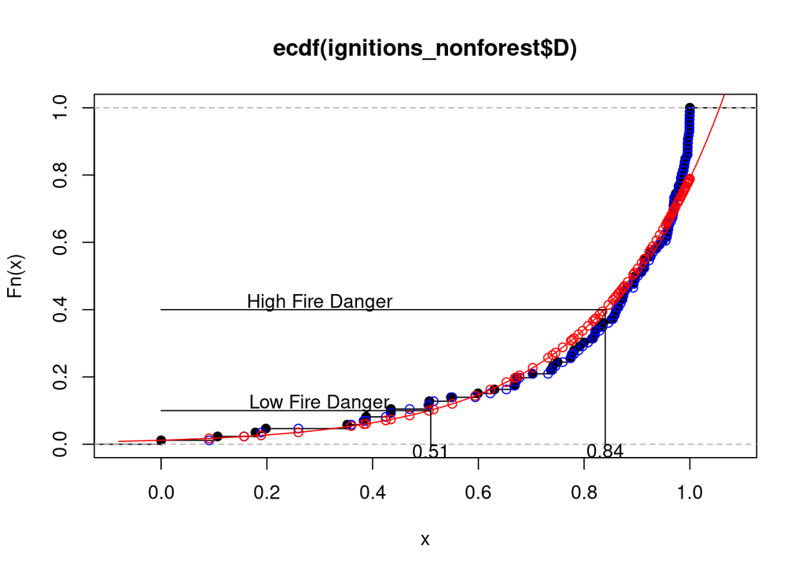

```r
ecdf_regression1_plot(ecdf_fn, estimated, a, b)
```

```r
regression_formulas <- regression_formulas %>%
    add_row(var = "D", order = "1", cover = "nonforest", formula = regression1_formula(a, b), r2 = r2)
```

Estimated function predicting proportion of historic fires burning in nonforests at or below given percentile of climatic water deficit on day of ignition:

$\begin{align*}f(x) = 0.0119265 e^{4.192916 x}\end{align*}$

### VPD Non-Forest

```r
ecdf_fn <- ecdf(ignitions_nonforest$VPD)
summary(ecdf_fn)
```

```
## Empirical CDF:     84 unique values with summary
##    Min. 1st Qu.  Median    Mean 3rd Qu.    Max.
## 0.04752 0.70940 0.88828 0.80706 0.98530 1.00000
```

```r
regression_list <- ecdf_regression1(ecdf_fn)
estimated <- regression_list$estimated
lm <- regression_list$lm
r2 <- summary(lm)$adj.r.squared
a <- regression_list$a
b <- regression_list$b

summary(lm)
```

```
##
## Call:
## lm(formula = log(proportions) ~ quants, data = estimated)
##
## Residuals:
##      Min       1Q   Median       3Q      Max
## -0.75777 -0.09800 -0.01799  0.10066  0.34878
##
## Coefficients:
##             Estimate Std. Error t value Pr(>|t|)
## (Intercept) -4.28308    0.06210  -68.97   <2e-16 ***
## quants       4.05960    0.07342   55.29   <2e-16 ***
## ---
## Signif. codes:  0 '***' 0.001 '**' 0.01 '*' 0.05 '.' 0.1 ' ' 1
##
## Residual standard error: 0.158 on 97 degrees of freedom
## Multiple R-squared:  0.9692, Adjusted R-squared:  0.9689
## F-statistic:  3057 on 1 and 97 DF,  p-value: < 2.2e-16
```

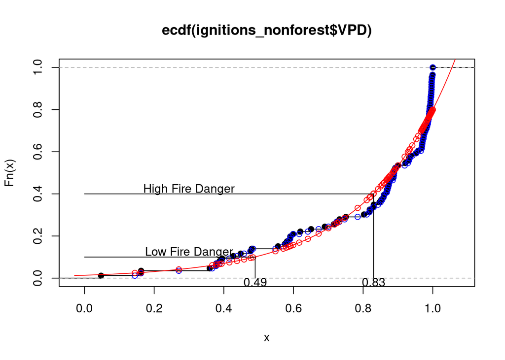

```r
ecdf_regression1_plot(ecdf_fn, estimated, a, b)
```

```r
regression_formulas <- regression_formulas %>%
    add_row(var = "VPD", order = "1", cover = "nonforest", formula = regression1_formula(a, b), r2 = r2)
```

Estimated function predicting proportion of historic fires burning in nonforests at or below given percentile of vapor pressure deficit on day of ignition:

$\begin{align*}f(x) = 0.0138001 e^{4.0595998 x}\end{align*}$

## Second Order

Fits to ECDF curves may be improved by including a quadtratic term in regression

### CWD Forest

```r
ecdf_fn <- ecdf(ignitions_forest$D)
summary(ecdf_fn)
```

```
## Empirical CDF:     151 unique values with summary
##    Min. 1st Qu.  Median    Mean 3rd Qu.    Max.
##  0.0000  0.7487  0.8914  0.8201  0.9779  1.0000
```

```r
estimated <- data.frame(
    dec = seq(from = 0.01, to = 0.99, by = 0.01)
)

estimated$quants <- quantile(ecdf_fn, estimated$dec)
estimated$proportions <- ecdf_fn(estimated$quants)

lm <- lm(log(proportions) ~ poly(quants, 2, raw = TRUE), data = estimated)
r2 <- summary(lm)$adj.r.squared
estimated$predicted <- exp(predict(lm, data = estimated$quants))

##plot(lm)

summary(lm)
```

```
##
## Call:
## lm(formula = log(proportions) ~ poly(quants, 2, raw = TRUE),
##     data = estimated)
##
## Residuals:
##      Min       1Q   Median       3Q      Max
## -0.54728 -0.04542 -0.02587  0.04746  0.27498
##
## Coefficients:
##                              Estimate Std. Error t value Pr(>|t|)
## (Intercept)                   -4.4075     0.0956 -46.104  < 2e-16 ***
## poly(quants, 2, raw = TRUE)1   3.6140     0.2976  12.142  < 2e-16 ***
## poly(quants, 2, raw = TRUE)2   0.6224     0.2170   2.868  0.00507 **
## ---
## Signif. codes:  0 '***' 0.001 '**' 0.01 '*' 0.05 '.' 0.1 ' ' 1
##
## Residual standard error: 0.09859 on 96 degrees of freedom
## Multiple R-squared:  0.9881, Adjusted R-squared:  0.9879
## F-statistic:  3995 on 2 and 96 DF,  p-value: < 2.2e-16
```

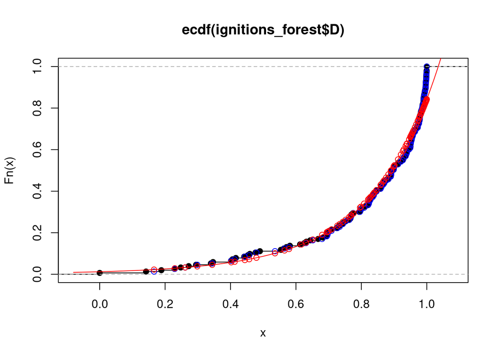

```r
b0 <- lm$coefficients[[1]]
b1 <- lm$coefficients[[2]]
b2 <- lm$coefficients[[3]]

plot(ecdf_fn)
points(y = estimated$proportions, x = estimated$quants, col = "blue")
points(y = estimated$predicted, x = estimated$quants, col = "red")
curve(exp(b0 + b1*x + b2*(x^2)), add = TRUE, col = "red")
```

```r
##curve(exp(predict(lm, newdata = data.frame(quants = x))), add = TRUE, col = "red")

regression_formulas <- regression_formulas %>%
    add_row(var = "D", order = "2", cover = "forest", formula = regression2_formula(b0, b1, b2), r2 = r2)
```

Estimated function predicting proportion of historic fires burning in forests at or below given percentile of CWD on day of ignition:

$\begin{align*}f(x) = e^{-4.4075261 + 3.6139803x + 0.6223984x^2}\end{align*}$

### VPD Forest

```r
ecdf_fn <- ecdf(ignitions_forest$VPD)
summary(ecdf_fn)
```

```
## Empirical CDF:     152 unique values with summary
##    Min. 1st Qu.  Median    Mean 3rd Qu.    Max.
## 0.01662 0.74359 0.90232 0.81565 0.97279 1.00000
```

```r
estimated <- data.frame(
    dec = seq(from = 0.01, to = 0.99, by = 0.01)
)

estimated$quants <- quantile(ecdf_fn, estimated$dec)
estimated$proportions <- ecdf_fn(estimated$quants)

lm <- lm(log(proportions) ~ poly(quants, 2, raw = TRUE), data = estimated)
r2 <- summary(lm)$adj.r.squared
estimated$predicted <- exp(predict(lm, data = estimated$quants))

##plot(lm)

summary(lm)
```

```
##
## Call:
## lm(formula = log(proportions) ~ poly(quants, 2, raw = TRUE),
##     data = estimated)
##
## Residuals:
##      Min       1Q   Median       3Q      Max
## -0.47226 -0.07360 -0.02422  0.06860  0.26431
##
## Coefficients:
##                               Estimate Std. Error t value Pr(>|t|)
## (Intercept)                  -4.558896   0.105344 -43.276   <2e-16 ***
## poly(quants, 2, raw = TRUE)1  4.378196   0.328886  13.312   <2e-16 ***
## poly(quants, 2, raw = TRUE)2 -0.006955   0.239211  -0.029    0.977
## ---
## Signif. codes:  0 '***' 0.001 '**' 0.01 '*' 0.05 '.' 0.1 ' ' 1
##
## Residual standard error: 0.1063 on 96 degrees of freedom
## Multiple R-squared:  0.9862, Adjusted R-squared:  0.9859
## F-statistic:  3430 on 2 and 96 DF,  p-value: < 2.2e-16
```

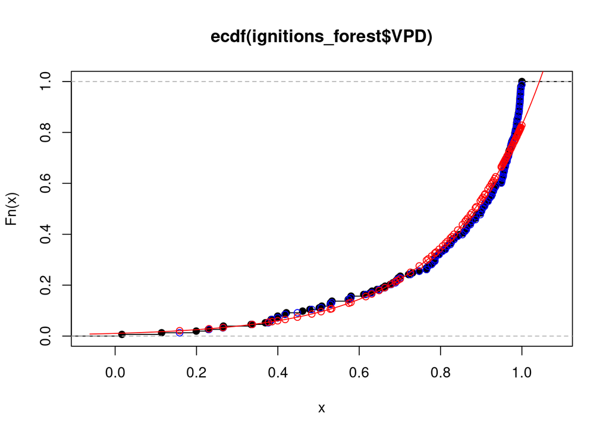

```r
b0 <- lm$coefficients[[1]]
b1 <- lm$coefficients[[2]]
b2 <- lm$coefficients[[3]]

plot(ecdf_fn)
points(y = estimated$proportions, x = estimated$quants, col = "blue")
points(y = estimated$predicted, x = estimated$quants, col = "red")
curve(exp(b0 + b1*x + b2*(x^2)), add = TRUE, col = "red")
```

```r
##curve(exp(predict(lm, newdata = data.frame(quants = x))), add = TRUE, col = "red")

regression_formulas <- regression_formulas %>%
    add_row(var = "VPD", order = "2", cover = "forest", formula = regression2_formula(b0, b1, b2), r2 = r2)
```

Estimated function predicting proportion of historic fires burning in forests at or below given percentile of VPD on day of ignition:

$\begin{align*}f(x) = e^{-4.5588956 + 4.3781964x + -0.006955x^2}\end{align*}$

### CWD Non-forest

```r
ecdf_fn <- ecdf(ignitions_nonforest$D)
summary(ecdf_fn)
```

```
## Empirical CDF:     86 unique values with summary
##    Min. 1st Qu.  Median    Mean 3rd Qu.    Max.
##  0.0000  0.7748  0.9015  0.8195  0.9772  1.0000
```

```r
estimated <- data.frame(
    dec = seq(from = 0.01, to = 0.99, by = 0.01)
)

estimated$quants <- quantile(ecdf_fn, estimated$dec)
estimated$proportions <- ecdf_fn(estimated$quants)

lm <- lm(log(proportions) ~ poly(quants, 2, raw = TRUE), data = estimated)
r2 <- summary(lm)$adj.r.squared
estimated$predicted <- exp(predict(lm, data = estimated$quants))

##plot(lm)

summary(lm)
```

```
##
## Call:
## lm(formula = log(proportions) ~ poly(quants, 2, raw = TRUE),
##     data = estimated)
##
## Residuals:
##      Min       1Q   Median       3Q      Max
## -0.62331 -0.06699 -0.02555  0.06489  0.26364
##
## Coefficients:
##                              Estimate Std. Error t value Pr(>|t|)
## (Intercept)                  -4.11131    0.09317 -44.125  < 2e-16 ***
## poly(quants, 2, raw = TRUE)1  3.00403    0.30300   9.914 2.27e-16 ***
## poly(quants, 2, raw = TRUE)2  0.91417    0.22884   3.995 0.000127 ***
## ---
## Signif. codes:  0 '***' 0.001 '**' 0.01 '*' 0.05 '.' 0.1 ' ' 1
##
## Residual standard error: 0.1192 on 96 degrees of freedom
## Multiple R-squared:  0.9827, Adjusted R-squared:  0.9823
## F-statistic:  2720 on 2 and 96 DF,  p-value: < 2.2e-16
```

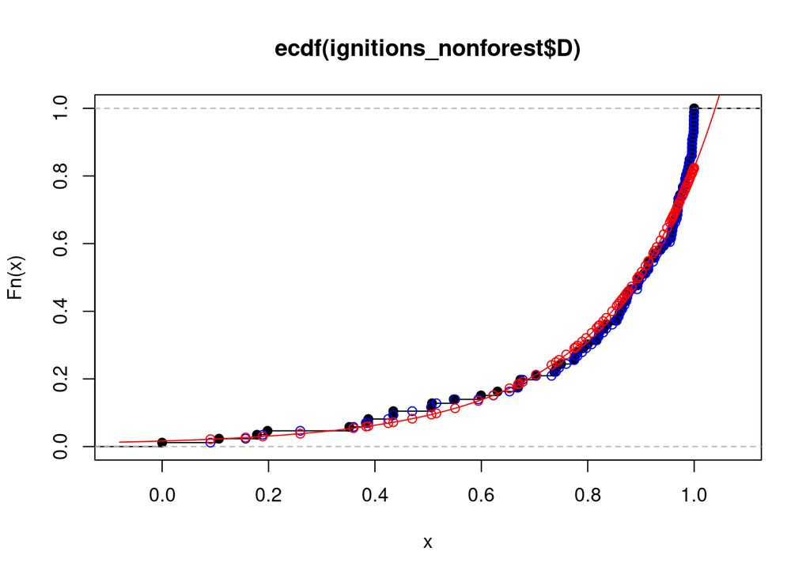

```r
b0 <- lm$coefficients[[1]]
b1 <- lm$coefficients[[2]]
b2 <- lm$coefficients[[3]]

plot(ecdf_fn)
points(y = estimated$proportions, x = estimated$quants, col = "blue")
points(y = estimated$predicted, x = estimated$quants, col = "red")
curve(exp(b0 + b1*x + b2*(x^2)), add = TRUE, col = "red")
```

```r
##curve(exp(predict(lm, newdata = data.frame(quants = x))), add = TRUE, col = "red")

regression_formulas <- regression_formulas %>%
    add_row(var = "D", order = "2", cover = "nonforest", formula = regression2_formula(b0, b1, b2), r2 = r2)
```

Estimated function predicting proportion of historic fires burning in nonforests at or below given percentile of CWD on day of ignition:

$\begin{align*}f(x) = e^{-4.1113085 + 3.004031x + 0.9141718x^2}\end{align*}$

### VPD Non-forest

```r
ecdf_fn <- ecdf(ignitions_nonforest$VPD)
summary(ecdf_fn)
```

```
## Empirical CDF:     84 unique values with summary
##    Min. 1st Qu.  Median    Mean 3rd Qu.    Max.
## 0.04752 0.70940 0.88828 0.80706 0.98530 1.00000
```

```r
estimated <- data.frame(
    dec = seq(from = 0.01, to = 0.99, by = 0.01)
)

estimated$quants <- quantile(ecdf_fn, estimated$dec)
estimated$proportions <- ecdf_fn(estimated$quants)

lm <- lm(log(proportions) ~ poly(quants, 2, raw = TRUE), data = estimated)
r2 <- summary(lm)$adj.r.squared
estimated$predicted <- exp(predict(lm, data = estimated$quants))

##plot(lm)

summary(lm)
```

```
##
## Call:
## lm(formula = log(proportions) ~ poly(quants, 2, raw = TRUE),
##     data = estimated)
##
## Residuals:
##      Min       1Q   Median       3Q      Max
## -0.59232 -0.09299 -0.01700  0.11712  0.32551
##
## Coefficients:
##                              Estimate Std. Error t value Pr(>|t|)
## (Intercept)                   -4.5826     0.1413 -32.424   <2e-16 ***
## poly(quants, 2, raw = TRUE)1   5.0988     0.4486  11.367   <2e-16 ***
## poly(quants, 2, raw = TRUE)2  -0.7691     0.3277  -2.347    0.021 *
## ---
## Signif. codes:  0 '***' 0.001 '**' 0.01 '*' 0.05 '.' 0.1 ' ' 1
##
## Residual standard error: 0.1544 on 96 degrees of freedom
## Multiple R-squared:  0.9709, Adjusted R-squared:  0.9703
## F-statistic:  1602 on 2 and 96 DF,  p-value: < 2.2e-16
```

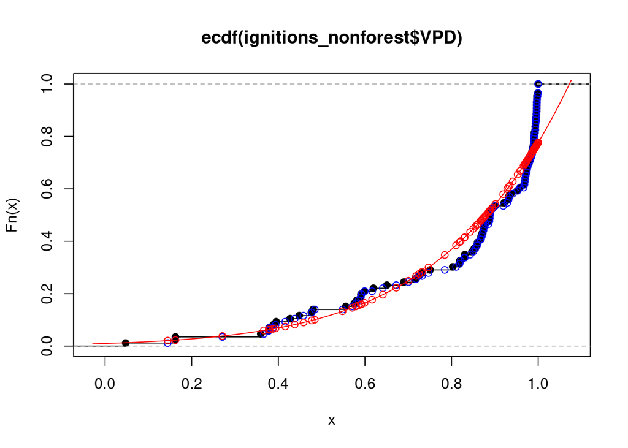

```r
b0 <- lm$coefficients[[1]]
b1 <- lm$coefficients[[2]]
b2 <- lm$coefficients[[3]]

plot(ecdf_fn)
points(y = estimated$proportions, x = estimated$quants, col = "blue")
points(y = estimated$predicted, x = estimated$quants, col = "red")
curve(exp(b0 + b1*x + b2*(x^2)), add = TRUE, col = "red")
```

```r
##curve(exp(predict(lm, newdata = data.frame(quants = x))), add = TRUE, col = "red")

regression_formulas <- regression_formulas %>%
    add_row(var = "VPD", order = "2", cover = "nonforest", formula = regression2_formula(b0, b1, b2), r2 = r2)
```

Estimated function predicting proportion of historic fires burning in nonforests at or below given percentile of VPD on day of ignition:

$\begin{align*}f(x) = e^{-4.5826099 + 5.0987721x + -0.7690767x^2}\end{align*}$

## Third Order

### CWD Forest

```r
ecdf_fn <- ecdf(ignitions_forest$D)
summary(ecdf_fn)
```

```
## Empirical CDF:     151 unique values with summary
##    Min. 1st Qu.  Median    Mean 3rd Qu.    Max.
##  0.0000  0.7487  0.8914  0.8201  0.9779  1.0000
```

```r
estimated <- data.frame(
    dec = seq(from = 0.01, to = 0.99, by = 0.01)
)

estimated$quants <- quantile(ecdf_fn, estimated$dec)
estimated$proportions <- ecdf_fn(estimated$quants)

lm <- lm(log(proportions) ~ poly(quants, 3, raw = TRUE), data = estimated)
r2 <- summary(lm)$adj.r.squared
estimated$predicted <- exp(predict(lm, data = estimated$quants))

##plot(lm)

summary(lm)
```

```
##
## Call:
## lm(formula = log(proportions) ~ poly(quants, 3, raw = TRUE),
##     data = estimated)
##
## Residuals:
##       Min        1Q    Median        3Q       Max
## -0.142013 -0.036181  0.000955  0.041161  0.145872
##
## Coefficients:
##                              Estimate Std. Error t value Pr(>|t|)
## (Intercept)                   -5.9987     0.1103  -54.37   <2e-16 ***
## poly(quants, 3, raw = TRUE)1  13.2616     0.6171   21.49   <2e-16 ***
## poly(quants, 3, raw = TRUE)2 -15.8955     1.0290  -15.45   <2e-16 ***
## poly(quants, 3, raw = TRUE)3   8.5349     0.5285   16.15   <2e-16 ***
## ---
## Signif. codes:  0 '***' 0.001 '**' 0.01 '*' 0.05 '.' 0.1 ' ' 1
##
## Residual standard error: 0.05121 on 95 degrees of freedom
## Multiple R-squared:  0.9968, Adjusted R-squared:  0.9967
## F-statistic:  9957 on 3 and 95 DF,  p-value: < 2.2e-16
```

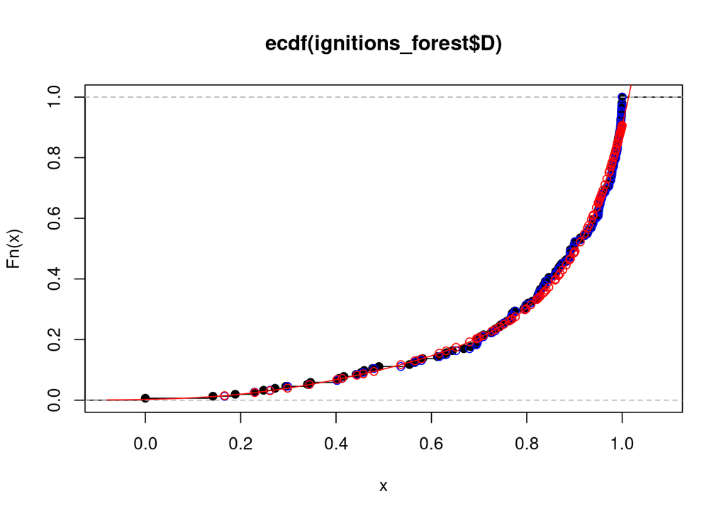

```r
b0 <- lm$coefficients[[1]]
b1 <- lm$coefficients[[2]]
b2 <- lm$coefficients[[3]]
b3 <- lm$coefficients[[4]]

plot(ecdf_fn)
points(y = estimated$proportions, x = estimated$quants, col = "blue")
points(y = estimated$predicted, x = estimated$quants, col = "red")
curve(exp(b0 + b1*x + b2*(x^2) + b3*(x^3)), add = TRUE, col = "red")
```

```r
##curve(exp(predict(lm, newdata = data.frame(quants = x))), add = TRUE, col = "red")

regression_formulas <- regression_formulas %>%
    add_row(var = "D", order = "3", cover = "forest", formula = regression3_formula(b0, b1, b2, b3), r2 = r2)
```

Estimated function predicting proportion of historic fires burning in forests at or below given percentile of CWD on day of ignition:

$\begin{align*}f(x) = e^{-5.998747 + 13.2616296x + -15.8955453x^2 + 8.5349086x^3}\end{align*}$

### VPD Forest

```r
ecdf_fn <- ecdf(ignitions_forest$VPD)
summary(ecdf_fn)
```

```
## Empirical CDF:     152 unique values with summary
##    Min. 1st Qu.  Median    Mean 3rd Qu.    Max.
## 0.01662 0.74359 0.90232 0.81565 0.97279 1.00000
```

```r
estimated <- data.frame(
    dec = seq(from = 0.01, to = 0.99, by = 0.01)
)

estimated$quants <- quantile(ecdf_fn, estimated$dec)
estimated$proportions <- ecdf_fn(estimated$quants)

lm <- lm(log(proportions) ~ poly(quants, 3, raw = TRUE), data = estimated)
r2 <- summary(lm)$adj.r.squared
estimated$predicted <- exp(predict(lm, data = estimated$quants))

##plot(lm)

summary(lm)
```

```
##
## Call:
## lm(formula = log(proportions) ~ poly(quants, 3, raw = TRUE),
##     data = estimated)
##
## Residuals:
##       Min        1Q    Median        3Q       Max
## -0.192425 -0.022484 -0.003376  0.026962  0.088180
##
## Coefficients:
##                               Estimate Std. Error t value Pr(>|t|)
## (Intercept)                   -6.28608    0.09062  -69.37   <2e-16 ***
## poly(quants, 3, raw = TRUE)1  14.82632    0.49997   29.66   <2e-16 ***
## poly(quants, 3, raw = TRUE)2 -18.03981    0.83648  -21.57   <2e-16 ***
## poly(quants, 3, raw = TRUE)3   9.40315    0.43315   21.71   <2e-16 ***
## ---
## Signif. codes:  0 '***' 0.001 '**' 0.01 '*' 0.05 '.' 0.1 ' ' 1
##
## Residual standard error: 0.04375 on 95 degrees of freedom
## Multiple R-squared:  0.9977, Adjusted R-squared:  0.9976
## F-statistic: 1.365e+04 on 3 and 95 DF,  p-value: < 2.2e-16
```

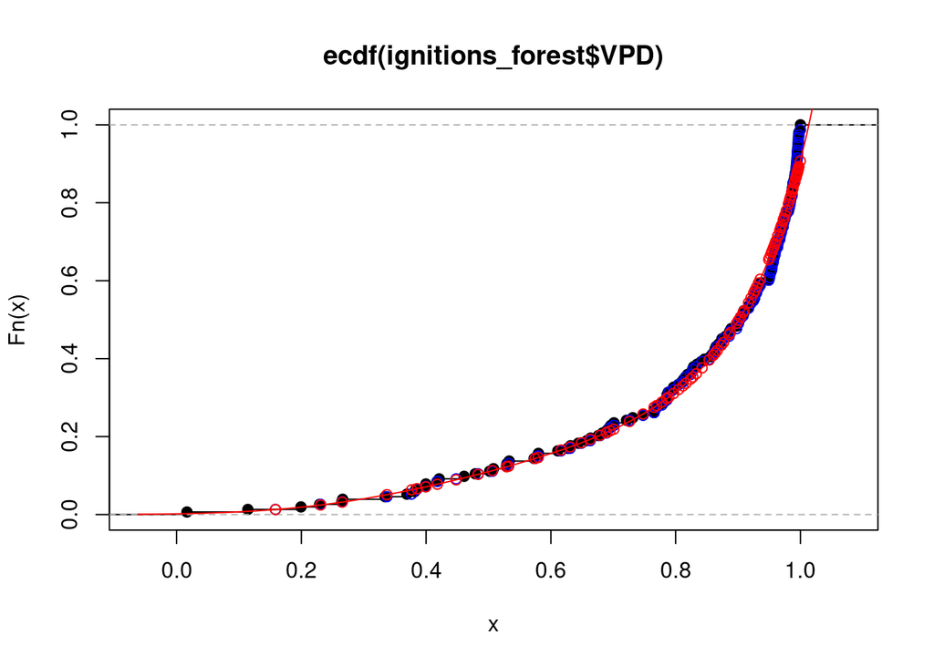

```r
b0 <- lm$coefficients[[1]]
b1 <- lm$coefficients[[2]]
b2 <- lm$coefficients[[3]]
b3 <- lm$coefficients[[4]]

plot(ecdf_fn)
points(y = estimated$proportions, x = estimated$quants, col = "blue")
points(y = estimated$predicted, x = estimated$quants, col = "red")
curve(exp(b0 + b1*x + b2*(x^2) + b3*(x^3)), add = TRUE, col = "red")
```

```r
##curve(exp(predict(lm, newdata = data.frame(quants = x))), add = TRUE, col = "red")

regression_formulas <- regression_formulas %>%
    add_row(var = "VPD", order = "3", cover = "forest", formula = regression3_formula(b0, b1, b2, b3), r2 = r2)
```

Estimated function predicting proportion of historic fires burning in forests at or below given percentile of VPD on day of ignition:

$\begin{align*}f(x) = e^{-6.2860803 + 14.8263175x + -18.0398113x^2 + 9.4031475x^3}\end{align*}$

### CWD Non-forest

```r
ecdf_fn <- ecdf(ignitions_nonforest$D)
summary(ecdf_fn)
```

```
## Empirical CDF:     86 unique values with summary
##    Min. 1st Qu.  Median    Mean 3rd Qu.    Max.
##  0.0000  0.7748  0.9015  0.8195  0.9772  1.0000
```

```r
estimated <- data.frame(
    dec = seq(from = 0.01, to = 0.99, by = 0.01)
)

estimated$quants <- quantile(ecdf_fn, estimated$dec)
estimated$proportions <- ecdf_fn(estimated$quants)

lm <- lm(log(proportions) ~ poly(quants, 3, raw = TRUE), data = estimated)
r2 <- summary(lm)$adj.r.squared
estimated$predicted <- exp(predict(lm, data = estimated$quants))

##plot(lm)

summary(lm)
```

```
##
## Call:
## lm(formula = log(proportions) ~ poly(quants, 3, raw = TRUE),
##     data = estimated)
##
## Residuals:
##       Min        1Q    Median        3Q       Max
## -0.154762 -0.029127 -0.000977  0.033943  0.215099
##
## Coefficients:
##                              Estimate Std. Error t value Pr(>|t|)
## (Intercept)                   -5.1959     0.0698  -74.44   <2e-16 ***
## poly(quants, 3, raw = TRUE)1  10.9446     0.4305   25.42   <2e-16 ***
## poly(quants, 3, raw = TRUE)2 -13.9862     0.7731  -18.09   <2e-16 ***
## poly(quants, 3, raw = TRUE)3   8.1364     0.4184   19.45   <2e-16 ***
## ---
## Signif. codes:  0 '***' 0.001 '**' 0.01 '*' 0.05 '.' 0.1 ' ' 1
##
## Residual standard error: 0.05369 on 95 degrees of freedom
## Multiple R-squared:  0.9965, Adjusted R-squared:  0.9964
## F-statistic:  9062 on 3 and 95 DF,  p-value: < 2.2e-16
```

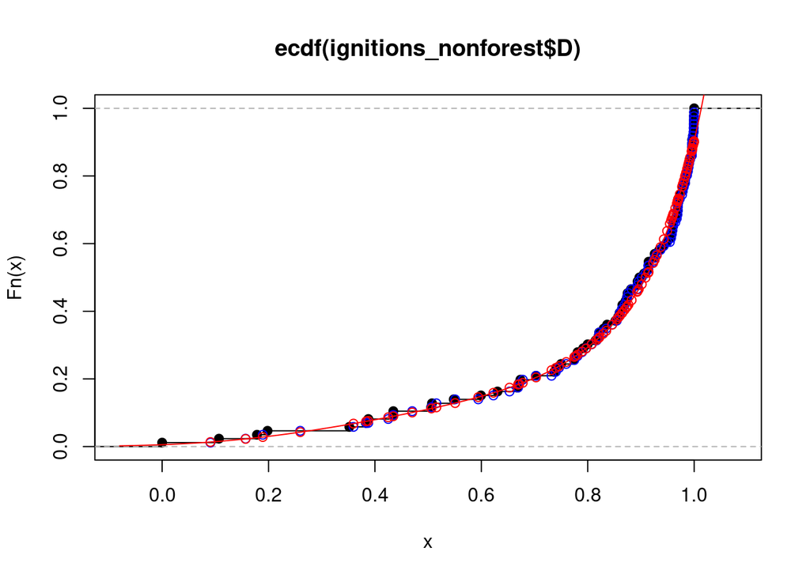

```r
b0 <- lm$coefficients[[1]]
b1 <- lm$coefficients[[2]]
b2 <- lm$coefficients[[3]]
b3 <- lm$coefficients[[4]]

plot(ecdf_fn)
points(y = estimated$proportions, x = estimated$quants, col = "blue")
points(y = estimated$predicted, x = estimated$quants, col = "red")
curve(exp(b0 + b1*x + b2*(x^2) + b3*(x^3)), add = TRUE, col = "red")
```

```r
##curve(exp(predict(lm, newdata = data.frame(quants = x))), add = TRUE, col = "red")

regression_formulas <- regression_formulas %>%
    add_row(var = "D", order = "3", cover = "nonforest", formula = regression3_formula(b0, b1, b2, b3), r2 = r2)
```

Estimated function predicting proportion of historic fires burning in nonforests at or below given percentile of CWD on day of ignition:

$\begin{align*}f(x) = e^{-5.1959413 + 10.9446545x + -13.9861859x^2 + 8.1364017x^3}\end{align*}$

### VPD Non-forest

```r
ecdf_fn <- ecdf(ignitions_nonforest$VPD)
summary(ecdf_fn)
```

```
## Empirical CDF:     84 unique values with summary
##    Min. 1st Qu.  Median    Mean 3rd Qu.    Max.
## 0.04752 0.70940 0.88828 0.80706 0.98530 1.00000
```

```r
estimated <- data.frame(
    dec = seq(from = 0.01, to = 0.99, by = 0.01)
)

estimated$quants <- quantile(ecdf_fn, estimated$dec)
estimated$proportions <- ecdf_fn(estimated$quants)

lm <- lm(log(proportions) ~ poly(quants, 3, raw = TRUE), data = estimated)
r2 <- summary(lm)$adj.r.squared
estimated$predicted <- exp(predict(lm, data = estimated$quants))

##plot(lm)

summary(lm)
```

```
##
## Call:
## lm(formula = log(proportions) ~ poly(quants, 3, raw = TRUE),
##     data = estimated)
##
## Residuals:
##      Min       1Q   Median       3Q      Max
## -0.41643 -0.06774 -0.00257  0.06069  0.39026
##
## Coefficients:
##                              Estimate Std. Error t value Pr(>|t|)
## (Intercept)                   -6.1516     0.1705  -36.08   <2e-16 ***
## poly(quants, 3, raw = TRUE)1  15.1109     0.9554   15.82   <2e-16 ***
## poly(quants, 3, raw = TRUE)2 -18.6871     1.6387  -11.40   <2e-16 ***
## poly(quants, 3, raw = TRUE)3   9.5663     0.8671   11.03   <2e-16 ***
## ---
## Signif. codes:  0 '***' 0.001 '**' 0.01 '*' 0.05 '.' 0.1 ' ' 1
##
## Residual standard error: 0.1028 on 95 degrees of freedom
## Multiple R-squared:  0.9873, Adjusted R-squared:  0.9868
## F-statistic:  2452 on 3 and 95 DF,  p-value: < 2.2e-16
```

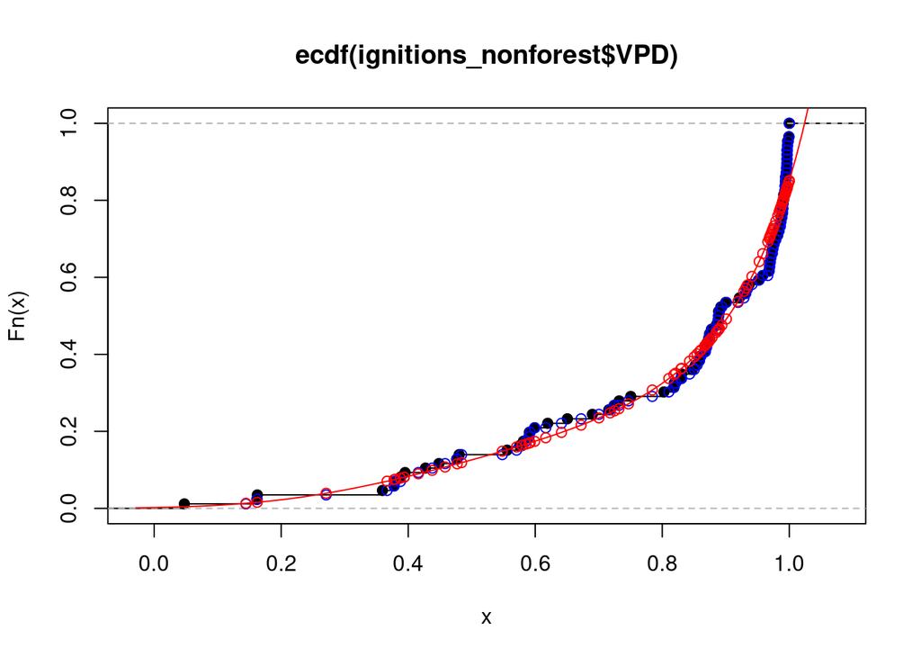

```r
b0 <- lm$coefficients[[1]]
b1 <- lm$coefficients[[2]]
b2 <- lm$coefficients[[3]]
b3 <- lm$coefficients[[4]]

plot(ecdf_fn)
points(y = estimated$proportions, x = estimated$quants, col = "blue")
points(y = estimated$predicted, x = estimated$quants, col = "red")
curve(exp(b0 + b1*x + b2*(x^2) + b3*(x^3)), add = TRUE, col = "red")
```

```r
##curve(exp(predict(lm, newdata = data.frame(quants = x))), add = TRUE, col = "red")

regression_formulas <- regression_formulas %>%
    add_row(var = "VPD", order = "3", cover = "nonforest", formula = regression3_formula(b0, b1, b2, b3), r2 = r2)
```

Estimated function predicting proportion of historic fires burning in nonforests at or below given percentile of VPD on day of ignition:

$\begin{align*}f(x) = e^{-6.151629 + 15.1109429x + -18.6870738x^2 + 9.566279x^3}\end{align*}$

## Estimated Regression Formulas

| cover | var | order | formula | r2 |
| --- | --- | --- | --- | --- |
| forest | D | 1 | y = 0.0095308e^(4.4556479x) | 0.9869762 |
| forest | VPD | 1 | y = 0.0105027e^(4.3687578x) | 0.9860576 |
| nonforest | D | 1 | y = 0.0119265e^(4.192916x) | 0.9795658 |
| nonforest | VPD | 1 | y = 0.0138001e^(4.0595998x) | 0.9689301 |
| forest | D | 2 | y = e^(-4.4075261 + 3.6139803x + 0.6223984x^2) | 0.9878793 |
| forest | VPD | 2 | y = e^(-4.5588956 + 4.3781964x + -0.006955x^2) | 0.9859124 |
| nonforest | D | 2 | y = e^(-4.1113085 + 3.004031x + 0.9141718x^2) | 0.9822960 |
| nonforest | VPD | 2 | y = e^(-4.5826099 + 5.0987721x + -0.7690767x^2) | 0.9703098 |
| forest | D | 3 | y = e^(-5.998747 + 13.2616296x + -15.8955453x^2 + 8.5349086x^3) | 0.9967297 |
| forest | VPD | 3 | y = e^(-6.2860803 + 14.8263175x + -18.0398113x^2 + 9.4031475x^3) | 0.9976118 |
| nonforest | D | 3 | y = e^(-5.1959413 + 10.9446545x + -13.9861859x^2 + 8.1364017x^3) | 0.9964079 |
| nonforest | VPD | 3 | y = e^(-6.151629 + 15.1109429x + -18.6870738x^2 + 9.566279x^3) | 0.9868478 |